# Data Visualization - Static Graphics using R

Brandon LeBeau

June 12, 2019

# Course Setup

```r
install.packages("tidyverse")
```

```r
library(tidyverse)
```

# Explore Data

| PID | county | state | area | poptotal | popdensity | popwhite | popblack | popamerindian | popasian | popother | percwhite | percblack | percamerindan | percasian | percother | popadults | perchsd | percollege | percprof | poppovertyknown | percpovertyknown | percbelowpoverty | percchildbelowpovert | percadultpoverty | percelderlypoverty | inmetro | category |
| --- | --- | --- | --- | --- | --- | --- | --- | --- | --- | --- | --- | --- | --- | --- | --- | --- | --- | --- | --- | --- | --- | --- | --- | --- | --- | --- | --- |
| 561 | ADAMS | IL | 0.052 | 66090 | 1270.9615 | 63917 | 1702 | 98 | 249 | 124 | 96.71206 | 2.57527614 | 0.14828264 | 0.37675897 | 0.18762294 | 43298 | 75.10740 | 19.631392 | 4.3558594 | 63628 | 96.27478 | 13.151443 | 18.011717 | 11.009776 | 12.443812 | 0 | AAR |
| 562 | ALEXANDER | IL | 0.014 | 10626 | 759.0000 | 7054 | 3496 | 19 | 48 | 9 | 66.38434 | 32.90043290 | 0.17880670 | 0.45172219 | 0.08469791 | 6724 | 59.72635 | 11.243308 | 2.8703153 | 10529 | 99.08714 | 32.244278 | 45.826514 | 27.385647 | 25.228976 | 0 | LHR |
| 563 | BOND | IL | 0.022 | 14991 | 681.4091 | 14477 | 429 | 35 | 16 | 34 | 96.57128 | 2.86171703 | 0.23347342 | 0.10673071 | 0.22680275 | 9669 | 69.33499 | 17.033819 | 4.4885717 | 14235 | 94.95697 | 12.068844 | 14.036061 | 10.852090 | 12.697410 | 0 | AAR |
| 564 | BOONE | IL | 0.017 | 30806 | 1812.1176 | 29344 | 127 | 46 | 150 | 1139 | 95.25417 | 0.41225735 | 0.14932156 | 0.48691813 | 3.69733169 | 19272 | 75.47219 | 17.278954 | 4.1977999 | 30337 | 98.47757 | 7.209019 | 11.179536 | 5.536013 | 6.217047 | 1 | ALU |
| 565 | BROWN | IL | 0.018 | 5836 | 324.2222 | 5264 | 547 | 14 | 5 | 6 | 90.19877 | 9.37285812 | 0.23989034 | 0.08567512 | 0.10281014 | 3979 | 68.86152 | 14.475999 | 3.3676803 | 4815 | 82.50514 | 13.520249 | 13.022889 | 11.143211 | 19.200000 | 0 | AAR |
| 566 | BUREAU | IL | 0.050 | 35688 | 713.7600 | 35157 | 50 | 65 | 195 | 221 | 98.51210 | 0.14010312 | 0.18213405 | 0.54640215 | 0.61925577 | 23444 | 76.62941 | 18.904624 | 3.2758915 | 35107 | 98.37200 | 10.399635 | 14.158819 | 8.179287 | 11.008586 | 0 | AAR |
| 567 | CALHOUN | IL | 0.017 | 5322 | 313.0588 | 5298 | 1 | 8 | 15 | 0 | 99.54904 | 0.01878993 | 0.15031943 | 0.28184893 | 0.00000000 | 3583 | 62.82445 | 11.917388 | 3.2096009 | 5241 | 98.47802 | 15.149781 | 13.787761 | 12.932331 | 21.085271 | 0 | LAR |
| 568 | CARROLL | IL | 0.027 | 16805 | 622.4074 | 16519 | 111 | 30 | 61 | 84 | 98.29813 | 0.66051770 | 0.17851830 | 0.36298721 | 0.49985123 | 11323 | 75.95160 | 16.197121 | 3.0557273 | 16455 | 97.91729 | 11.710726 | 17.225462 | 10.027037 | 9.525052 | 0 | AAR |
| 569 | CASS | IL | 0.024 | 13437 | 559.8750 | 13384 | 16 | 8 | 23 | 6 | 99.60557 | 0.11907420 | 0.05953710 | 0.17116916 | 0.04465282 | 8825 | 72.27195 | 14.107649 | 3.2067989 | 13081 | 97.35060 | 13.875086 | 17.994784 | 11.914343 | 13.660180 | 0 | AAR |
| 570 | CHAMPAIGN | IL | 0.058 | 173025 | 2983.1897 | 146506 | 16559 | 331 | 8033 | 1596 | 84.67331 | 9.57029331 | 0.19130183 | 4.64268169 | 0.92241006 | 95971 | 87.49935 | 41.295808 | 17.7574476 | 154934 | 89.54429 | 15.572437 | 14.132234 | 17.562728 | 8.105017 | 1 | HAU |

[output cut: 427 more lines]

# First ggplot

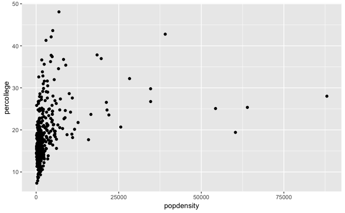

```r
ggplot(data = midwest) +
  geom_point(mapping = aes(x = popdensity, y = percollege))
```

# Equivalent Code

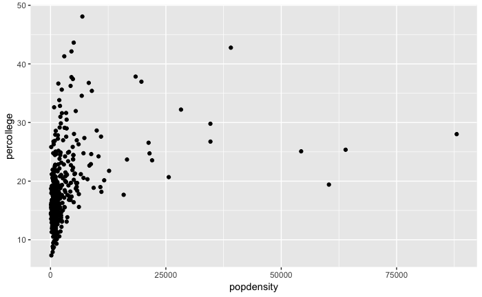

```r
ggplot(midwest) +
  geom_point(aes(x = popdensity, y = percollege))
```

# Your Turn

1. Try plotting `popdensity` by `state`.
2. Try plotting `county` by `state`.
   - Does this plot work?
3. Bonus: Try just using the `ggplot(data = midwest)` from above.
   - What do you get?
   - Does this make sense?

# Add Aesthetics

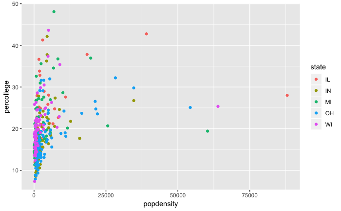

```r
ggplot(midwest) +
  geom_point(aes(x = popdensity, y = percollege, color = state))
```

# Global Aesthetics

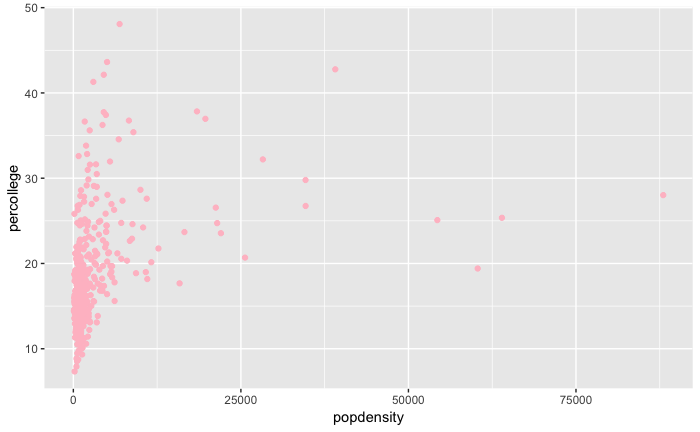

```r
ggplot(midwest) +
  geom_point(aes(x = popdensity, y = percollege), color = 'pink')
```

# Your Turn

1. Instead of using colors, make the shape of the points different for each state.
2. Instead of color, use `alpha` instead.
   - What does this do to the plot?
3. Try the following command: `colors()`.
   - Try a few colors to find your favorite.
4. What happens if you use the following code:

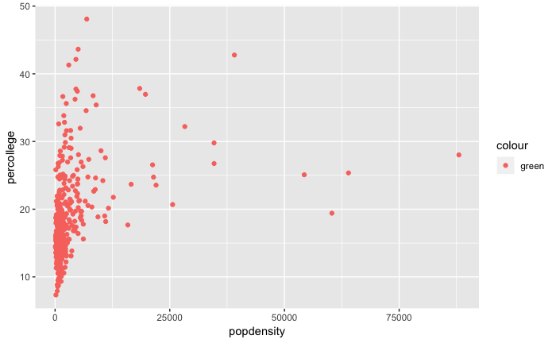

```r
ggplot(midwest) +
  geom_point(aes(x = popdensity, y = percollege, color = 'green'))
```

# Additional Geoms

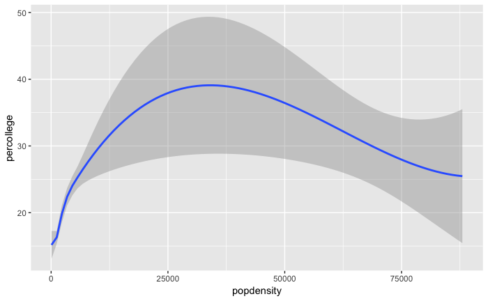

```r
ggplot(midwest) +
  geom_smooth(aes(x = popdensity, y = percollege))
```

# Add more Aesthetics

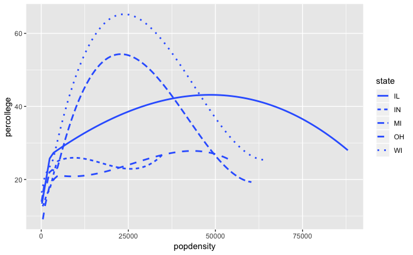

```r
ggplot(midwest) +
  geom_smooth(aes(x = popdensity, y = percollege, linetype = state),
              se = FALSE)
```

# Your Turn

# Layered ggplot

```r
ggplot(midwest) +
  geom_point(aes(x = popdensity, y = percollege, color = state)) +
  geom_smooth(aes(x = popdensity, y = percollege, color = state),
              se = FALSE)
```

[output not shown]

# Remove duplicate aesthetics

```r
ggplot(midwest,
       aes(x = popdensity, y = percollege, color = state)) +
  geom_point() +
  geom_smooth(se = FALSE)
```

[output not shown]

# Your Turn

1. Can you recreate the following figure?

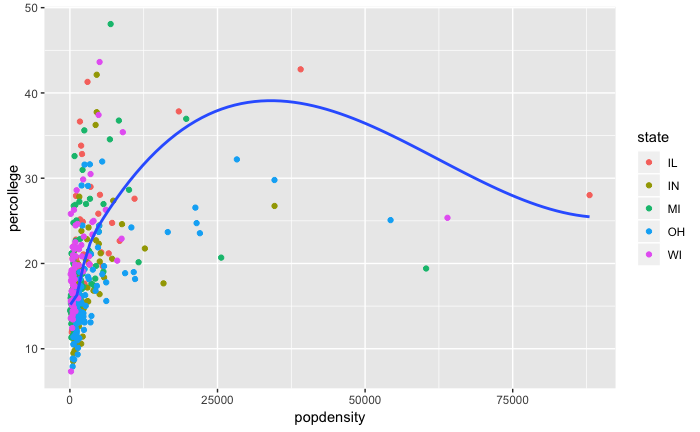

# Brief plot customization

```r
ggplot(midwest,
       aes(x = popdensity, y = percollege, color = state)) +
  geom_point() +
  scale_x_continuous("Population Density",
                     breaks = seq(0, 80000, 20000)) +
  scale_y_continuous("Percent College Graduates") +
  scale_color_discrete("State")
```

# Brief plot customization Output

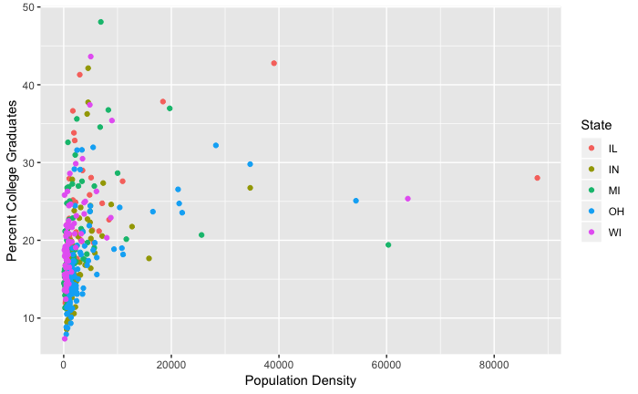

# Change plot theme

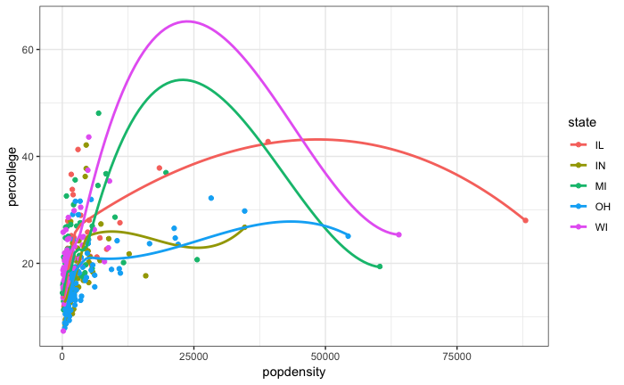

```r
ggplot(midwest,
       aes(x = popdensity, y = percollege, color = state)) +
  geom_point() +
  geom_smooth(se = FALSE) +
  theme_bw()
```

# More themes

- Themes in ggplot2: http://ggplot2.tidyverse.org/reference/ggtheme.html
- Themes from ggthemes package: https://cran.r-project.org/web/packages/ggthemes/vignettes/ggthemes.html

# Base plot for reference

```r
p1 <- ggplot(midwest,
       aes(x = popdensity, y = percollege, color = state)) +
  geom_point() +
  scale_x_continuous("Population Density",
                     breaks = seq(0, 80000, 20000)) +
  scale_y_continuous("Percent College Graduates") +
  theme_bw()
```

# Add plot title or subtitle

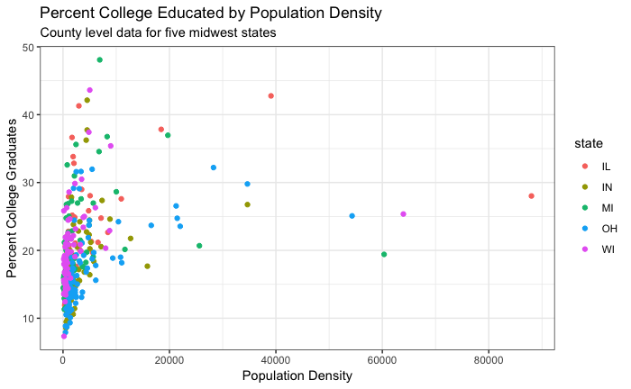

```r
p1 +
  labs(title = "Percent College Educated by Population Density",
       subtitle = "County level data for five midwest states")
```

# Color Options

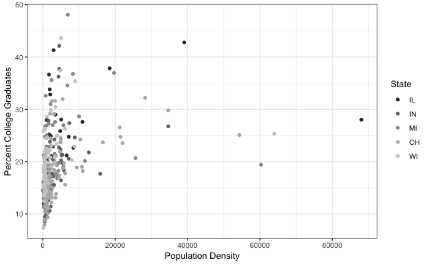

```r
p1 + scale_color_grey("State")
```

# Using colorbrewer2.org

- http://colorbrewer2.org

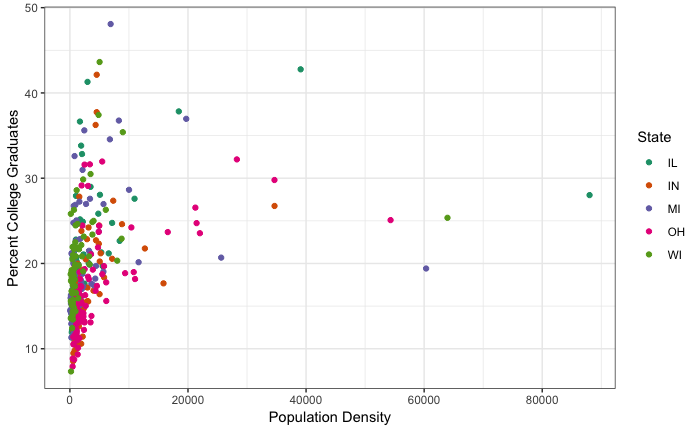

```r
p1 + scale_color_brewer("State", palette = 'Dark2')
```

# Two additional color options

- viridis: https://github.com/sjmgarnier/viridis
- scico: https://github.com/thomasp85/scico

# viridis colors

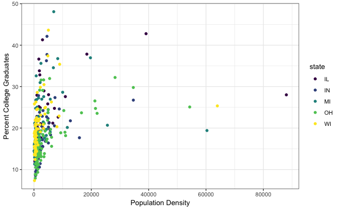

```r
library(viridis)
p1 + scale_color_viridis(discrete = TRUE)
```

# viridis colors

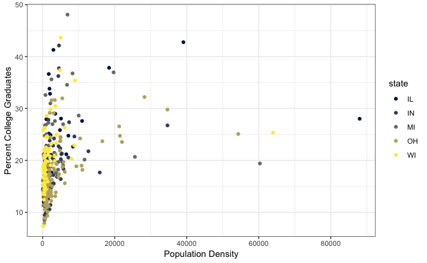

```r
p1 + scale_color_viridis(option = 'cividis', discrete = TRUE)
```

# Zoom in on a plot

```r
ggplot(data = midwest,
       aes(x = popdensity, y = percollege, color = state)) +
  geom_point() +
  scale_x_continuous("Population Density") +
  scale_y_continuous("Percent College Graduates") +
  scale_color_discrete("State") +
  coord_cartesian(xlim = c(0, 15000))
```

# Zoom in on a plot output

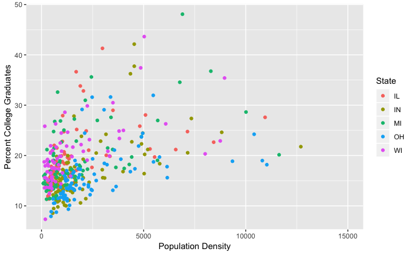

# Zoom using `scale_x_continuous` - Bad Practice

```r
ggplot(data = midwest,
       aes(x = popdensity, y = percollege, color = state)) +
  geom_point() +
  geom_smooth(se = FALSE) +
  scale_x_continuous("Population Density", limits = c(0, 15000)) +
  scale_y_continuous("Percent College Graduates") +
  scale_color_discrete("State")
```

# Comparing output

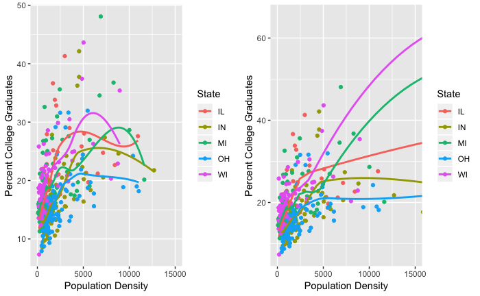

# Lord of the Rings Data

- Data from Jenny Bryan: https://github.com/jennybc/lotr

```r
lotr <- read_tsv('https://raw.githubusercontent.com/jennybc/lotr/master/lotr_clean.tsv')
lotr
```

| Film | Chapter | Character | Race | Words |
| --- | --- | --- | --- | --- |
| The Fellowship Of The Ring | 01: Prologue | Bilbo | Hobbit | 4 |
| The Fellowship Of The Ring | 01: Prologue | Elrond | Elf | 5 |
| The Fellowship Of The Ring | 01: Prologue | Galadriel | Elf | 460 |
| The Fellowship Of The Ring | 02: Concerning Hobbits | Bilbo | Hobbit | 214 |
| The Fellowship Of The Ring | 03: The Shire | Bilbo | Hobbit | 70 |
| The Fellowship Of The Ring | 03: The Shire | Frodo | Hobbit | 128 |
| The Fellowship Of The Ring | 03: The Shire | Gandalf | Wizard | 197 |
| The Fellowship Of The Ring | 03: The Shire | Hobbit Kids | Hobbit | 10 |
| The Fellowship Of The Ring | 03: The Shire | Hobbits | Hobbit | 12 |
| The Fellowship Of The Ring | 04: Very Old Friends | Bilbo | Hobbit | 339 |

[output cut: 672 more lines]

# Geoms for single variables

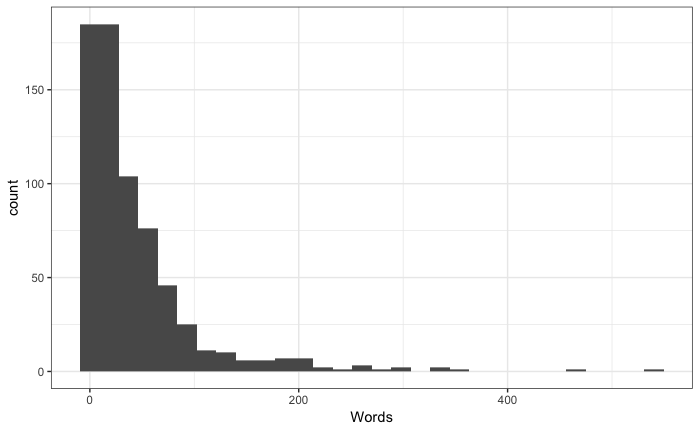

```r
ggplot(lotr, aes(x = Words)) +
  geom_histogram() +
  theme_bw()
```

# Customize histogram

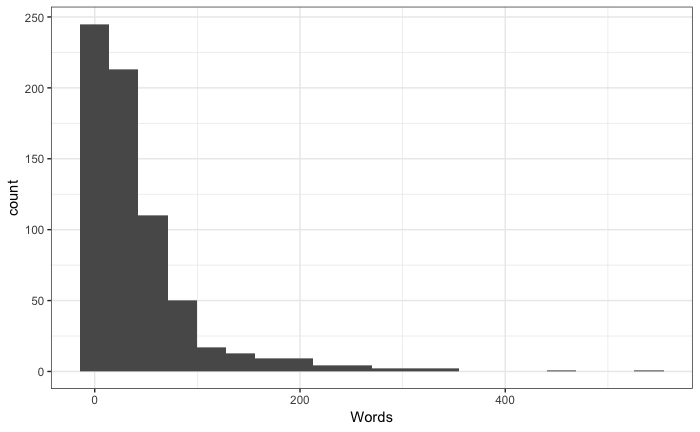

```r
ggplot(lotr, aes(x = Words)) +
  geom_histogram(bins = 20) +
  theme_bw()
```

# Customize histogram 2

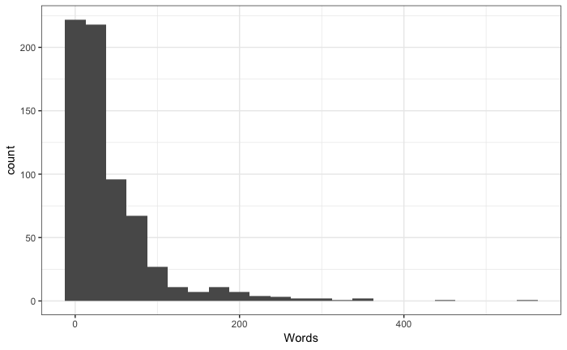

```r
ggplot(lotr, aes(x = Words)) +
  geom_histogram(binwidth = 25) +
  theme_bw()
```

# Histograms by other variables - likely not useful

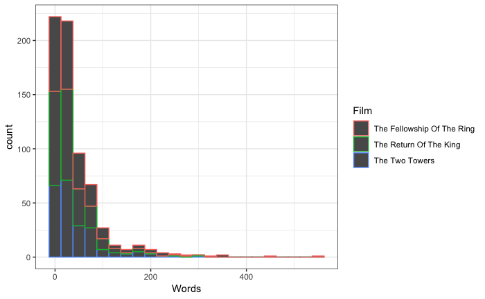

```r
ggplot(lotr, aes(x = Words, color = Film)) +
  geom_histogram(binwidth = 25) +
  theme_bw()
```

# Histograms by other variables - one alternative

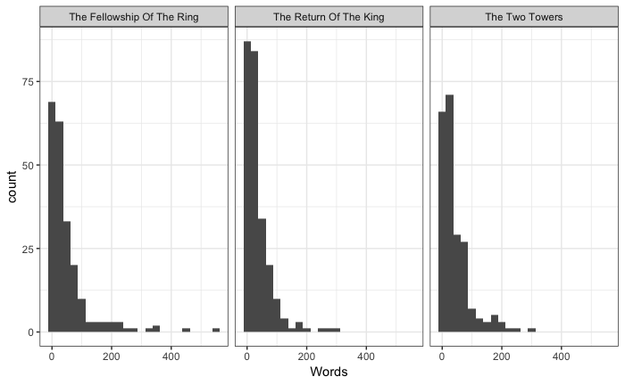

```r
ggplot(lotr, aes(x = Words)) +
  geom_histogram(binwidth = 25) +
  theme_bw() +
  facet_wrap(~ Film)
```

# Your Turn

1. With more than two groups, histograms are difficult to interpret due to overlap. Instead, use the `geom_density` to create a density plot for `Words` for each film.
2. Using `geom_boxplot`, create boxplots with `Words` as the y variable and `Film` as the x variable. Bonus: facet this plot by the variable `Race`. Bonus2: Zoom in on the bulk of the data.

# Rotation of axis labels

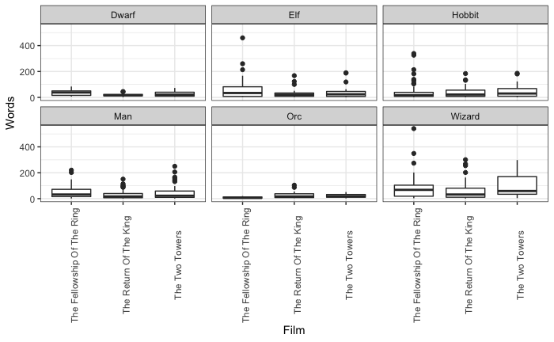

```r
ggplot(lotr, aes(x = Film, y = Words)) +
  geom_boxplot() +
  facet_wrap(~ Race) +
  theme_bw() +
  theme(axis.text.x = element_text(angle = 90))
```

# Many times `coord_flip` is better

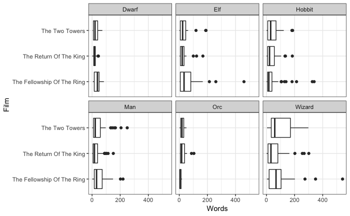

```r
ggplot(lotr, aes(x = Film, y = Words)) +
  geom_boxplot() +
  facet_wrap(~ Race) +
  theme_bw() +
  coord_flip()
```

# Bar graphs

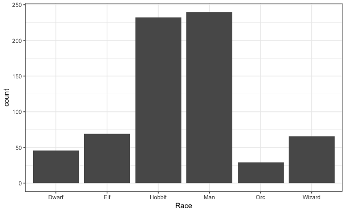

```r
ggplot(lotr, aes(x = Race)) +
  geom_bar() +
  theme_bw()
```